# SQLQuestionsAndAnswers1

### SQL Question and Answers

#### SQL assignment 2.docx

1. Create a customer table which comprises of these columns – ‘customer_id’, ‘first_name’, ‘last_name’, ‘email’, ‘address’, ‘city’,’state’,’zip’

```python
create table Customer (customer_id int, first_name varchar(15), last_name varchar(10),email varchar(30), address varchar(20), city varchar(20), state varchar(15), zip int)
```

2. Insert 5 new records into the table

```python
INSERT INTO customer (customer_id, first_name,last_name,email, Address, City, state, zip)
VALUES ('001', 'Tom', 'Jerry', 'tom@gmail.com', ' T-nagar,chennai', 'Chennai','TamilNadu',641014),
('002', 'Yogitha', 'Shan', 'yogi@gmail.com', ' Anna nagar,chennai', 'Chennai','TamilNadu',641084),
('003', 'Gayu', 'priya', 'Gayu@gmail.com', '305 - 14th Ave. S. Suite 3B', 'San Jose','USA',98128),
('004', 'vicky', 'da', 'vicky@gmail.com', 'ul. Filtrowa 68', 'Helsinki','Finland',98128),
('005', 'sai', 'prasad', 'sai@gmail.com', 'Keskuskatu 45', 'Walla','poland',21240);
```

3. Select only the ‘first_name’ & ‘last_name’ columns from the customer table

```python
select first_name as First_Name, last_name as Last_Name
from Customer
```

4. Select those records where ‘first_name’ starts with “G” and city is ‘San Jose’

```python
select *
from Customer
where first_name like 'G%' and city='San Jose'
```

#### SQL-assignment 3.docx

1. Create an ‘Orders’ table which comprises of these columns – ‘order_id’, ‘order_date’, ‘amount’, ‘customer_id’

```python
create table Orders (order_id int, order_date date, amount int, customer_id int)
```

2. Make an inner join on ‘Customer’ & ‘Order’ tables on the ‘customer_id’ column

```python
select * from Customer
inner join Orders
on Customer.customer_id = Orders.customer_id
```

3. Make left and right joins on ‘Customer’ & ‘Order’ tables on the ‘customer_id’ column

```python
# Left join

select * from Customer
left join Orders
on Customer.customer_id = Orders.customer_id

# Right Join

select * from Customer
right join Orders
on Customer.customer_id = Orders.customer_id
```

4. Update the ‘Orders’ table, set the amount to be 100 where ‘customer_id’ is 3

```python
update orders
set amount=100
where customer_id=3
```

#### SQL-assignment 4.docx

1. Use the inbuilt functions and find the minimum, maximum and average amount from the orders table

```python
select Min(amount) as Minimum_Amount ,Max(amount)as Maximum_Amount,Avg(amount)as Average_Amount
from Orders
```

2. Create a user-defined function, which will multiply the given number with 10

```python
CREATE FUNCTION multiply
(@a AS INT -- parameter a
)
RETURNS INT -- return type
AS
BEGIN
RETURN @a * 10 -- return statement
END;
```

3. Use the case statement to check if 100 is less than 200, greater than 200 or equal to 200 and print the corresponding value

```python
select
case when 100<200 then '100 is less than 200'
when 100>200 then '100 is greater than 200'
when 100=200 then '100 is equal to 200'
end as result
```

#### SQL-Module-5 assignment.docx

1. Arrange the ‘Orders’ dataset in decreasing order of amount

```python
select *
from orders
order by amount desc
```

2. Create a table with name ‘Employee_details1’ and comprising of these columns – ‘Emp_id’, ‘Emp_name’, ‘Emp_salary’. Create another table with name ‘Employee_details2’, which comprises of same columns as first table.

```python
create table Employee_details1
(Emp_id int,
Emp_name varchar(50),
Emp_salary int)


create table Employee_details2
(Emp_id int,
Emp_name varchar(50),
Emp_salary int)
```

3. Apply the union operator on these two tables

```python
select emp_id from EMPLOYEE_DETAILS1
union
select emp_id from EMPLOYEE_DETAILS2
```

4. Apply the intersect operator on these two tables

```python
select emp_id from EMPLOYEE_DETAILS1
intersect
select emp_id from EMPLOYEE_DETAILS2
```

5. Apply the except operator on these two tables

```python
select a.emp_id,a.emp_name
from EMPLOYEE_DETAILS1 a
inner join EMPLOYEE_DETAILS2 b
on a.emp_id=b.emp_id

except

select b.emp_id,b.emp_name
from EMPLOYEE_DETAILS2 a
inner join EMPLOYEE_DETAILS1 b
on a.emp_id=b.emp_id
```

#### SQL-New-Assignment-6.docx

Employee Table

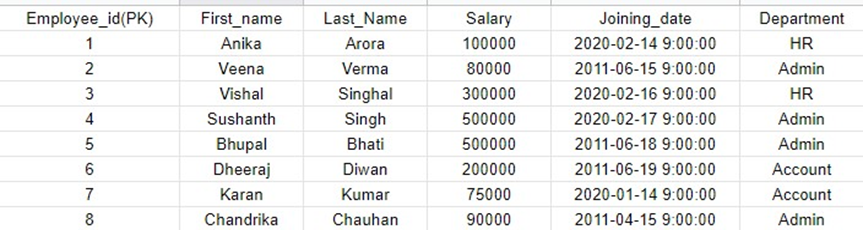

Employee Bonus Table

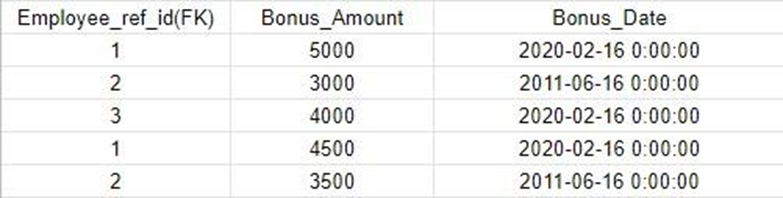

Employee Title Table

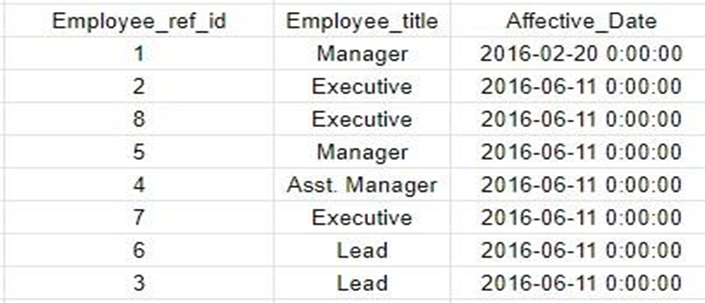

1. Display the “FIRST_NAME” from Employee table using the alias name as Employee_name.

```python
select FIRST_NAME as Employee_name
from employee
```

2. Display “LAST_NAME” from Employee table in upper case.

```python
select upper(last_name) as last_name
from employee
```

3. Display unique values of DEPARTMENT from EMPLOYEE table.

```python
SELECT DISTINCT department
FROM employee;
```

4. Display the first three characters of LAST_NAME from EMPLOYEE table.

```python
select left(last_name,3)
from employee
```

5. Display the unique values of DEPARTMENT from EMPLOYEE table and prints its length.

```python
select distinct department,len(department) as length_value
from employee
```

6. Display the FIRST_NAME and LAST_NAME from EMPLOYEE table into a single column AS FULL_NAME. a space char should separate them.

```python
select concat(First_Name,'  ',Last_Name) AS Full_Name
from employee
```

7. DISPLAY all EMPLOYEE details from the employee table order by FIRST_NAME Ascending.

```python
select * from employee
order by first_name asc
```

8. Display all EMPLOYEE details order by FIRST_NAME Ascending and DEPARTMENT Descending.

```python
select * from employee
order by first_name asc, last_name DESC
```

9. Display details for EMPLOYEE with the first name as “VEENA” and “KARAN” from EMPLOYEE table.

```python
select * from employee
where first_name in (‘VEENA’,’KARAN’);
```

10. Display details of EMPLOYEE with DEPARTMENT name as “Admin”.

```python
select * from employee
where department=’ADMIN’
```

11. DISPLAY details of the EMPLOYEES whose FIRST_NAME contains ‘V’.

```python
select * from employee
WHERE first_name LIKE '%a%';
```

12. DISPLAY details of the EMPLOYEES whose SALARY lies between 100000 and 500000.

```python
select * from employee
WHERE salary BETWEEN 100000 AND 500000;
```

13. Display details of the employees who have joined in Feb-2020.

```python
select * from employee
where YEAR(joining_date)=2020 and month(joining_date)=02
```

14. Display employee names with salaries >= 50000 and <= 100000.

```python
select concat(first_name,' ',last_name) as name from employee
where employee_id  IN (select employee_id from employee
Where Salary BETWEEN 50000 AND 100000);
```

15. DISPLAY details of the EMPLOYEES who are also Managers.

```python
select  e.first_name,e.last_name,e1.employee_title
from employee e
inner join employee_title e1
on e.employee_id=e1.employee_ref_id
where e1.employee='Manager'
```

16. DISPLAY duplicate records having matching data in some fields of a table.

```python
WITH EmployeesCTE as
(
   SELECT*, ROW_NUMBER() over (PARTITION BY ID ORDER BY ID) as RowNumber
   FROM Employee
)
Select *  FROM EmployeesCTE WHERE RowNumber>1
```

17. Display only odd rows from a table.

```python
SELECT * FROM (
    SELECT *, Row_Number() OVER(ORDER BY employee_id) AS RowNumber FROM employee) t
WHERE t.RowNumber % 2 <> 0
```

18. Clone a new table from EMPLOYEE table.

```python
CREATE TABLE new_table select * employee ;
INSERT INTO new_table SELECT * FROM employee;
```

19. DISPLAY the TOP 2 highest salary from a table.

```python
WITH T AS
(
SELECT *,
   DENSE_RANK() OVER (ORDER BY salary  Desc) AS Rnk
FROM employee
)
SELECT salary FROM T  where Rnk in (1,2);
```

20. DISPLAY the list of employees with the same salary.

```python
SELECT * FROM employee
WHERE salary IN     (SELECT salary      FROM employee e
WHERE employee.employee_id <> e.employee_id);
```

21. Display the second highest salary from a table.

```python
select *from employee
where salary=(select Max(salary) from employee);
```

22. Display the first 50% records from a table.

```python
select top 50 percent *
from Employee;
```

23 number is missing, but maintaining as same as docx file

24. Display the departments that have less than 4 people in it.

```python
select department from employee
group by department having count(*)<4;
```

25. Display all departments along with the number of people in there.

```python
select department ,count(*) from employee
group by department
```

26. Display the name of employees having the highest salary in each department.

```python
select department ,max(salary) from employee
group by department
```

27. Display the names of employees who earn the highest salary.

```python
select * from employee
where salary=(select max(salary) from employee);
```

28. Diplay the average salaries for each department

```python
select department ,AVG(salary) from employee
group by department
```

29. display the name of the employee who has got maximum bonus

```python
select concat(e.First_Name,'  ',e.Last_Name) AS Full_Name from employee e inner join employee_bonus b
On e.employee_id=b.employee_ref_id where max(b.bonus_amount)
```

30. Display the first name and title of all the employees

```python
select e.first_name,b.employee_title
from employee e
inner join employee_title b
On e.employee_id=b.employee_ref_id
```